# Sheet 1

```python
import numpy as np
import matplotlib.pyplot as plt
from matplotlib import pyplot as plt
%matplotlib inline
```

## 1 Principal Component Analysis

### (a)

```python
# TODO: implement PCA (fill in the blanks in the function below)

def pca(data, n_components=None):
    """
    Principal Component Analysis on a p x N data matrix.

    Parameters
    ----------
    data : np.ndarray
        Data matrix of shape (p, N).
    n_components : int, optional
        Number of requested components. By default returns all components.

    Returns
    -------
    np.ndarray, np.ndarray
        the pca components (shape (n_components, p)) and the projection (shape (n_components, N))

    """
        # Set n_components to p by default
    n_components = data.shape[0] if n_components is None else n_components
    assert n_components <= data.shape[0], "n_components must be less than or equal to the dimensionality of data."

    # Center the data
    data_centered = data - np.mean(data, axis=1, keepdims=True)

    # Compute covariance matrix
    covariance_matrix = np.matmul(data_centered, data_centered.T)

    # Compute eigenvalues and eigenvectors
    eigenvalues, eigenvectors = np.linalg.eigh(covariance_matrix)

    # Sort the eigenvalues and corresponding eigenvectors in descending order
    sorted_indices = np.argsort(eigenvalues)[::-1]
    sorted_eigenvectors = eigenvectors[:, sorted_indices]

    # Select the top n_components eigenvectors
    components = sorted_eigenvectors[:, :n_components].T

    # Compute the projected data
    #X_projected = np.linalg.inv(components.T @ components) @ (components.T @ data_centered)
    X_projected = components @ data_centered

    return components, X_projected
  # return the n_components first components and the pca projection of the data
```

```python
# Example data to test your implementation
# All the asserts on the bottom should go through if your implementation is correct

data = np.array([
    [ 1,  0,  0, -1,  0,  0],
    [ 0,  3,  0,  0, -3,  0],
    [ 0,  0,  5,  0,  0, -5]
], dtype=np.float32)

# add a random offset to all samples. it should not affect the results
data += np.random.randn(data.shape[0], 1)

n_components = 2
components, projection = pca(data, n_components=n_components)  # apply your implementation

# the correct results are known (up to some signs)
true_components = np.array([[0, 0, 1], [0, 1, 0]], dtype=np.float32)
true_projection = np.array([
    [ 0,  0,  5,  0,  0, -5],
    [ 0,  3,  0,  0, -3,  0]
], dtype=np.float32)

# check that components match, up to sign
assert isinstance(components, np.ndarray), f'Expected components to be numpy array but got {type(components)}'
assert components.shape == true_components.shape, f'{components.shape}!={true_components.shape}'
assert np.allclose(np.abs(components * true_components).sum(1), np.ones(n_components)), f'Components not matching'

# check that projections agree, taking into account potentially flipped components
assert isinstance(projection, np.ndarray), f'Expected projection to be numpy array but got {type(projection)}'
assert projection.shape == (n_components, data.shape[1]), f'Incorrect shape of projection: Expected {(n_components, data.shape[1])}, got {projection.shape}'
assert np.allclose(projection, true_projection * (components * true_components).sum(1, keepdims=True), atol=1e-6), f'Projections not matching'

print('Test successful!')
```

```
Test successful!
```

### (b)

Load the data (it is a subset of the data at https://opendata.cern.ch/record/4910#)

```python
features = np.load('data/dijet_features.npy')
labels = np.load('data/dijet_labels.npy')
label_names = ['b', 'c', 'q']  # bottom, charm or light quarks

print(f'{features.shape=}, {labels.shape=}')  # print the shapes

# TODO: print how many samples of each class are present in the data (hint: numpy.unique)
labelnumbers, labelcounts = np.unique(labels, return_counts=True)  # print the unique labels and their counts

for index in range(len(label_names)):
    print('label names: ',label_names[index],'numbercode: ', int(labelnumbers[index]), 'count: ', labelcounts[index])
```

```
features.shape=(116, 2233), labels.shape=(2233,)
label names:  b numbercode:  0 count:  999
label names:  c numbercode:  1 count:  864
label names:  q numbercode:  2 count:  370
```

Normalize the data

```python
# TODO: report range of features and normalize the data to zero mean and unit variance
feature_range = np.ptp(features, axis = 1)
print('highest feature range: ', max(feature_range))
print('lowest feature range: ', min(feature_range))
print('feature range mean', np.mean(feature_range))
print('feature range std', np.std(feature_range))
features_means = np.mean(features, axis=1, keepdims=True)
features_std = np.std(features, axis=1, keepdims=True)


features_normalized = (features - features_means) / features_std
```

```
highest feature range:  2576772.606923904
lowest feature range:  0.021708244174450164
feature range mean 272486.8839102684
feature range std 683687.0490197014
```

### (c)

Compute a 2D PCA projection and make a scatterplot of the result, once without color, once coloring the dots by label. Interpret your results.

```python
# TODO: apply PCA as implemented in (a)
n_components = 2
_, features_pca = pca(features_normalized, n_components=n_components)
print(np.shape(features_pca))
print(np.iscomplexobj(features_normalized), np.iscomplexobj(features_pca))
```

```
(2, 2233)
False False
```

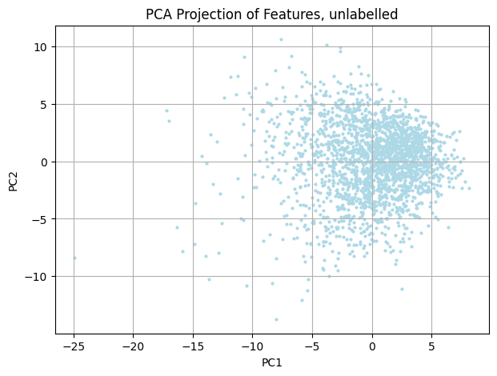

```python
# TODO: make a scatterplot of the PCA projection

plt.figure(figsize=(7, 5))

scatter = plt.scatter(features_pca[0,:], features_pca[1,:], color = 'lightblue', alpha=1, s=4)
plt.title('PCA Projection of Features, unlabelled')
plt.xlabel('PC1')
plt.ylabel('PC2')
plt.grid(True)
plt.show()
```

Interpretation: It appears, that there is just one big cluster, that fades out to one side more than to the other. Without labeling the different flavours, it is not possible to discern distinct regions.

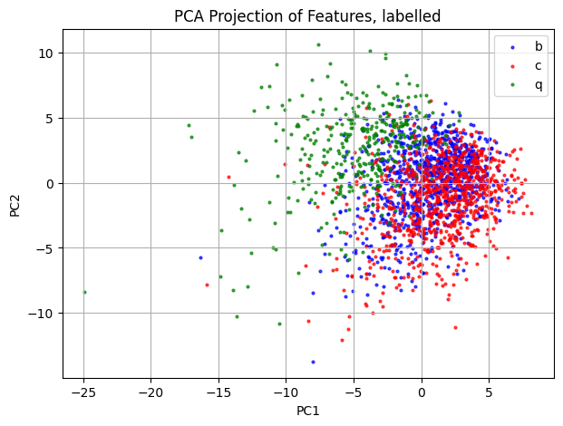

```python
# TODO: make a scatterplot, coloring the dots by their label and including a legend with the label names
# (hint: one way is to call plt.scatter once for each of the three possible labels. Why could it be problematic to scatter the data sorted by labels though?)

#create masks
mask0 = labels == 0
mask1 = labels == 1
mask2 = labels == 2

plt.figure(figsize=(7, 5))

scatter = plt.scatter(features_pca[0,:][mask0], features_pca[1,:][mask0], color = 'blue', label = 'b', alpha=0.7, s = 4)
scatter = plt.scatter(features_pca[0,:][mask1], features_pca[1,:][mask1], color = 'red', label = 'c',alpha = 0.7, s=4)
scatter = plt.scatter(features_pca[0,:][mask2], features_pca[1,:][mask2], color = 'green', label = 'q', alpha = 0.7, s=4)
plt.title('PCA Projection of Features, labelled')
plt.legend()
plt.xlabel('PC1')
plt.ylabel('PC2')
plt.grid(True)
plt.show()
```

Now, that the flavours are labelled by colour one can see the tendency of samples of the same kind to form clusters. However, they are not distinct. The projection after PCA of the charm(red) and bottom(blue) pairs of quarks is close to congruent. The projection of the pair of light quark(green) datase does overlap with the others, but only for a small fraction of their respective area. Further, the green data appears to be more spread out than the blue and red data. However, because there are much less green datapoints compared to red and blue, it is hard to draw conclusions based on the impression of density.

## 2 Nonlinear Dimension Reduction

```python
import umap  # import umap-learn, see https://umap-learn.readthedocs.io/
```

```python
# if you have not done 1(b) yet, you can load the normalized features directly:
features = np.load('data/dijet_features_normalized.npy')
labels = np.load('data/dijet_labels.npy')
label_names = ['b', 'c', 'q']  # bottom, charm or light quarks
```

### (a)

```python
# TODO: Apply umap on the normalized jet features from excercise 1. It will take a couple of seconds.
# note: umap uses a different convention regarding the feature- and sample dimension, N x p instead of p x N!

reducer = umap.UMAP()
reduced_features = reducer.fit_transform(features_normalized.T).T
reduced_features.shape
```

```
(2, 2233)
```

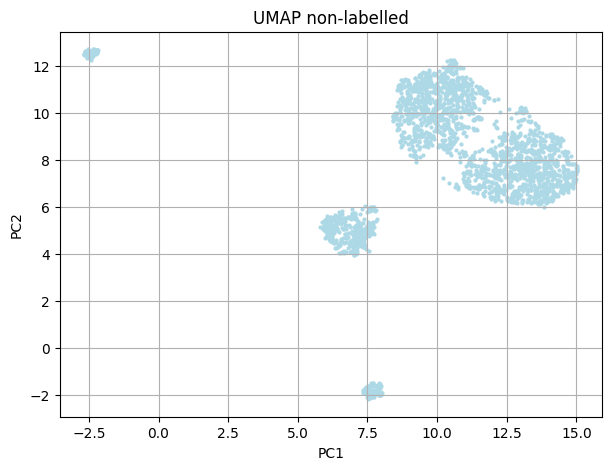

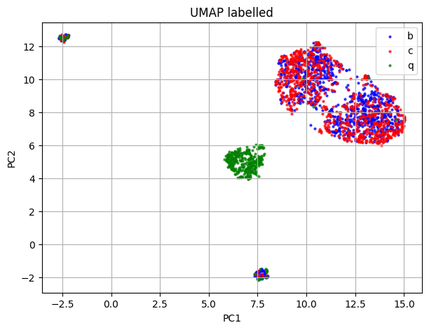

```python
# TODO: make a scatterplot of the UMAP projection
plt.figure(figsize=(7, 5))

scatter = plt.scatter(reduced_features[0,:], reduced_features[1,:], color = 'lightblue', alpha=1, s= 4)
plt.title('UMAP non-labelled')
plt.xlabel('PC1')
plt.ylabel('PC2')
plt.grid(True)
plt.show()

#print(np.iscomplexobj(features_pca))
# TODO: make a scatterplot, coloring the dots by their label and including a legend with the label names
#create masks

mask0 = labels == 0
mask1 = labels == 1
mask2 = labels == 2
masks = [mask0, mask1, mask2]

plt.figure(figsize=(7, 5))

plt.scatter(reduced_features[0,:][mask0], reduced_features[1,:][mask0], color = 'blue', label = 'b', alpha=0.7, s=4)
plt.scatter(reduced_features[0,:][mask1], reduced_features[1,:][mask1], color = 'red', label = 'c',alpha = 0.7, s=4)
plt.scatter(reduced_features[0,:][mask2], reduced_features[1,:][mask2], color = 'green', label = 'q', alpha = 0.7, s=4)
plt.title('UMAP labelled')

plt.legend()
plt.xlabel('PC1')
plt.ylabel('PC2')
plt.grid(True)
plt.show()
```

In the first figure, on can see 5 clusters. 3 are fully seperated by each other, while the remaining 2 are distinguishable, but close to each other. If the ground truth label is visualized in the second figure, it can be observed, that the central cluster is solely composed of green data points. The 2 smaller clusters contain data from each label, while the 2 remaining large clusters contain no green data points at all. UMAP tells that the green data (pair of light quarks), behaves different compared to the other labels. The UMAP model was able to distingusih the data better than PCA. However, it took way longer to compute.

### (b)

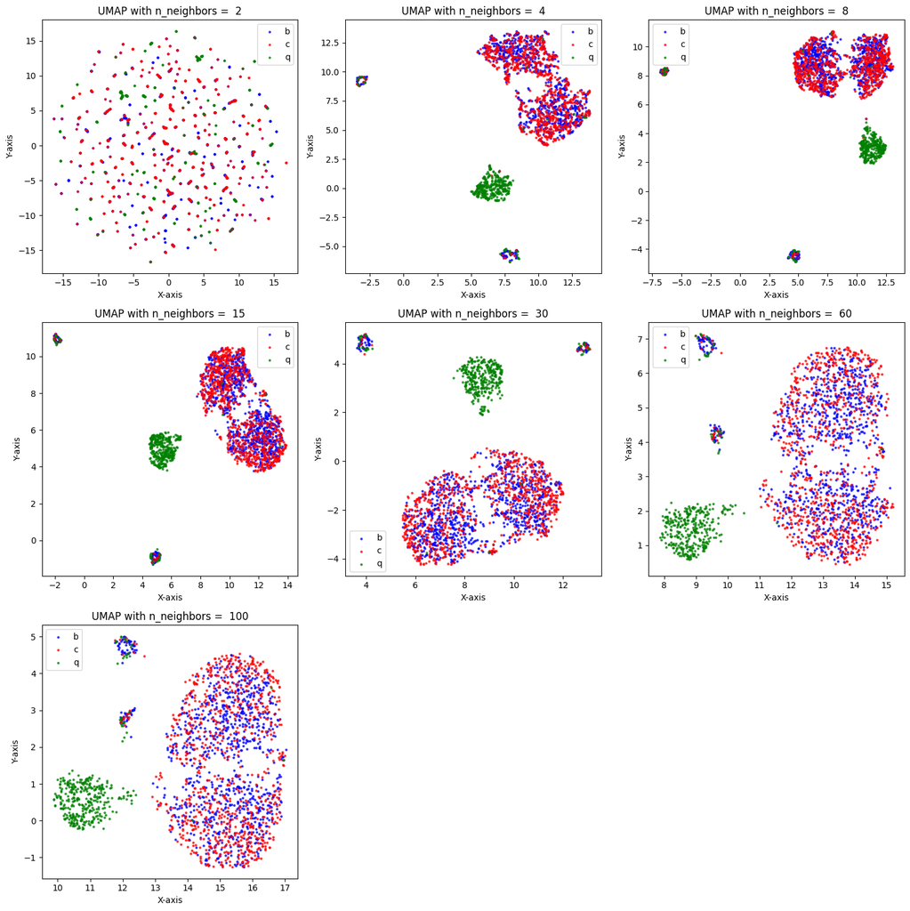

```python
#for n_neighbors in (2, 4, 8, 15, 30, 60, 100):
# Number of subplots
n_neighbors = np.array([2, 4, 8, 15, 30, 60, 100])

# Number of columns (subplots per row)
num_cols = 3

# Calculate number of rows needed
num_rows = (len(n_neighbors) + num_cols - 1) // num_cols  # Ceiling division

# Create a figure and a set of subplots
fig, axs = plt.subplots(num_rows, num_cols, figsize=(15, 5 * num_rows))

# Flatten the axs array for easier indexing
axs = axs.flatten()

# Example data and plotting
for i,n in enumerate(n_neighbors):
    # Example function that changes with i
    reducer = umap.UMAP(n_neighbors=n)
    features_umap = reducer.fit_transform(features_normalized.T).T
    axs[i].scatter(features_umap[0,:][mask0], features_umap[1,:][mask0], color = 'blue', label = 'b', alpha=0.7, s=4)
    axs[i].scatter(features_umap[0,:][mask1], features_umap[1,:][mask1], color = 'red', label = 'c', alpha = 0.7, s=4)
    axs[i].scatter(features_umap[0,:][mask2], features_umap[1,:][mask2], color = 'green', label = 'q', alpha = 0.7, s=4)
    axs[i].set_title(f'UMAP with n_neighbors =  {n}')
    axs[i].set_xlabel('X-axis')
    axs[i].set_ylabel('Y-axis')
    axs[i].legend()


# Hide any unused subplots
for j in range(len(n_neighbors), len(axs)):
    axs[j].axis('off')

# Adjust layout
plt.tight_layout()
plt.show()
```

One can see, that the resulting 2D Projection heavily depends on the choice of neighbors. n=2 does not project the underlying structure of the data into 2d, it can be disregarded and should not be chosen for interpretation. For low n (4<=n<=15), the method works well, the proximity of the labels in the data is mapped into 2D. For medium n=30, one can see that the data is still clustered, but starts to fade at the edges. This happens, because if more neighbors are included into the computation, the result is more smooth, but can also transport less information about local structures. For high n (n>=60), the data is more and more spread out, starting to leak into each other. This is indicative, that the choice of n might be too high.